# Lab 13: Solutions

1. Suppose you have the following data on population for two countries for two years. Reshape this data so that each country’s population is in a separate column, and each year is on just one row. Give the new variables informative names.

```r
library(tidyverse)
data <- data.frame(year=c(1,1,2,2), country=c("a","b","a","b"), pop=c(1,2,3,4))
data
```

```
##   year country pop
## 1    1       a   1
## 2    1       b   2
## 3    2       a   3
## 4    2       b   4
```

```r
data_wide <- spread(data, key=country, value=pop)
data_wide
```

```
##   year a b
## 1    1 1 2
## 2    2 3 4
```

2. Convert your result from above back to a long data frame,i.e. back to its original shape.

```r
data_long <- gather(data_wide, key=country, value=pop, a, b)
data_long
```

```
##   year country pop
## 1    1       a   1
## 2    2       a   3
## 3    1       b   2
## 4    2       b   4
```

3. Run the code below. Would you say that the resulting data frame is wide or long?

```r
#put tickers of a bunch of stocks in a vector
stocks <- c("FB","AMZN","AAPL", "GE") #facebook, amazon, apple, GE
data <- data.frame() #create an empty data frame
#make a loop that grabs the tickers from the 'stocks' vector and gets the data from yahoo finance
for (i in 1:length(stocks)) {
  temp <- read_csv(paste("https://www.quandl.com/api/v3/datasets/WIKI/",stocks[i],".csv", sep=""))
  temp$stock <- stocks[i] #create a key that is the stock ticker
  temp <- temp %>% rename(close=`Adj. Close`) %>% #rename adj. close
                   select(Date, stock, close) #keep only Date, stock and Adj.Close
  #append temp to data, this will gradually stack data for each stock on top of each other
  data <- bind_rows(data,temp)
}
data <- filter(data, Date>as.Date("2003-01-01")) #trim the time frame
```

We have companies stacked on top of each other. This is decidedly a “long” data set.

4. Use the above data frame to create a time plot of stock prices of all four companies in one graph. Use a log scale on the y-axis. (Hint: You can map the color aesthetic to `stock`.)

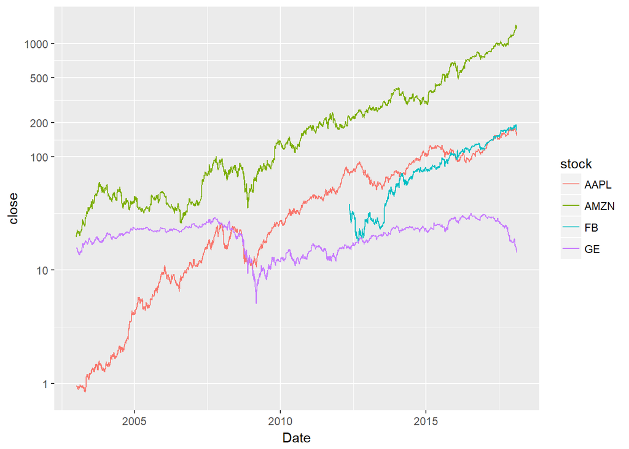

```r
ggplot(data, aes(x=Date, y=close, color=stock)) + geom_line() +
  scale_y_continuous(trans="log", breaks=c(1,10,100,200,500,1000))
```

5. Turn your data from long to wide with stock prices for each company as separate columns. Do you have any missing values? Why?

```r
data_wide <- spread(data, value=close, key=stock)
```

We have missing values because not all stocks started trading before 2003. For example, Facebook only started trading in May 2012 - so we have missing values for Facebook from 2003 to May 2012.

6. Calculate the correlation coefficients among the four stock prices. (Hint 1: Use function `cor()` which takes as an argument a data frame of *numerical* variables. Hint 2: Use option `use="pariwise.complete.obs` to tell the function to ignore missing values in each pair of variables.) Which pair of stock prices has the lowest correlation coefficient? Which has the highest? Does that make sense to you?

```r
cor <- cor(select(data_wide, AAPL, FB, AMZN, GE), use="pairwise.complete.obs")
cor <- cor(select(data_wide, -Date), use="pairwise.complete.obs") #same thing as above
cor
```

```
##           AAPL      AMZN        FB        GE
## AAPL 1.0000000 0.9248257 0.9024879 0.3701385
## AMZN 0.9248257 1.0000000 0.9540276 0.4182952
## FB   0.9024879 0.9540276 1.0000000 0.5213548
## GE   0.3701385 0.4182952 0.5213548 1.0000000
```

The correlations are pretty high. The three technology companies (Apple, Facebook, Amazon) have pretty high correlations. GE being an industrial conglomerate has fairly low correlations with the other three.

7. Use package `corrplot` to visualize the correlations. See the documentation [here](https://cran.r-project.org/web/packages/corrplot/vignettes/corrplot-intro.html) (Hint: You need to put the output of `cor()` into a matrix object, like this `correlations <- cor()`.)

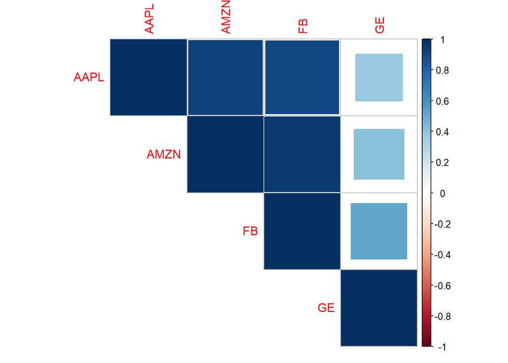

```r
library(corrplot)
corrplot(cor, type="upper", method="square")
```